# Lecture3_Rcode

Nemanja Vaci

February 23, 2021

Adding more variables to our data. It just keeps growing:

```r
set.seed(456)
Babies=data.frame(Age=round(runif(100,1,30)), Weight=rnorm(100,4000,500))
Babies$Height=rnorm(100,40+0.2*Babies$Age+0.004*Babies$Weight, 5)
Babies$Gender=rbinom(100,1,0.5)
Babies$Crawl=rbinom(100,1,0.031*Babies$Age+0.00001*Babies$Weight-0.06*Babies$Gender)
Babies$TummySleep=rbinom(100,1,0.5)
Babies$PhysicalSt=rnorm(100,10+0.3*Babies$Height+0.1*Babies$Age-0.06*Babies$Gender+0.15*Babies$TummySleep,5)
Babies$Gender=as.factor(Babies$Gender)
levels(Babies$Gender)=c('Girls','Boys')
```

Fitting the model:

```r
#install.packages('lavaan') - we need lavaan package to fit structural equation models, both path models and confirmatory factor analysis
require(lavaan)
model1<-'
Height~1+Age #regression
'##The model is written between two apostrophes and R sees this as a text values
fit1<-sem(model1, data=Babies) #we use sem function to fit the model, while we specify that data is in the dataset Babies
```

Comparing with the regression:

```r
lm1<-lm(Height~Age, data=Babies)
summary(lm1)
```

```
##
## Call:
## lm(formula = Height ~ Age, data = Babies)
##
## Residuals:
##      Min       1Q   Median       3Q      Max
## -14.4765  -4.1601  -0.3703   3.9198  12.3842
##
## Coefficients:
##             Estimate Std. Error t value Pr(>|t|)
## (Intercept) 57.02580    1.18751  48.021   <2e-16 ***
## Age          0.14317    0.06426   2.228   0.0282 *
## ---
## Signif. codes:  0 '***' 0.001 '**' 0.01 '*' 0.05 '.' 0.1 ' ' 1
##
## Residual standard error: 5.283 on 98 degrees of freedom
## Multiple R-squared:  0.04821,    Adjusted R-squared:  0.0385
## F-statistic: 4.964 on 1 and 98 DF,  p-value: 0.02817
```

We can also plot the estimates of our model:

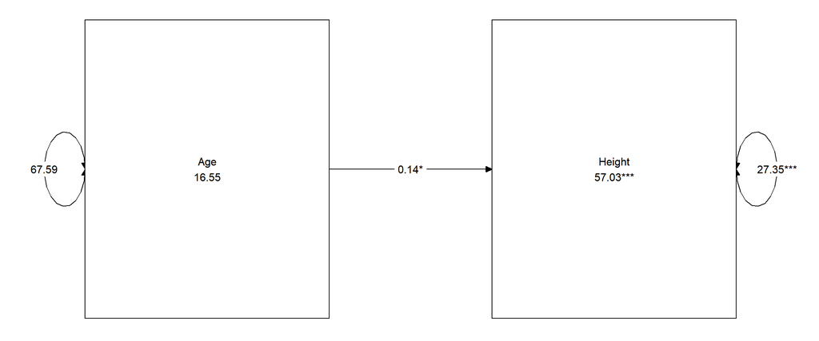

```r
#install.packages('tidySEM')
require('tidySEM')
graph_sem(fit1, variance_diameter=.2)
```

This will not add an interaction!

```r
model2<-'
Height~1+Age*Weight
'#What * does in this case is that it adds a label to the Weight predictor. This is behaviour only related to sem
fit2<-sem(model2, data=Babies)
summary(fit2)
```

```
## lavaan 0.6-7 ended normally after 14 iterations
##
##   Estimator                                         ML
##   Optimization method                           NLMINB
##   Number of free parameters                          3
##
##   Number of observations                           100
##
## Model Test User Model:
##
##   Test statistic                                 0.000
##   Degrees of freedom                                 0
##
## Parameter Estimates:
##
##   Standard errors                             Standard
##   Information                                 Expected
##   Information saturated (h1) model          Structured
##
## Regressions:
##                    Estimate    Std.Err  z-value  P(>|z|)
##   Height ~
##     Weight   (Age)      0.004    0.001    4.209    0.000
##
## Intercepts:
##                    Estimate    Std.Err  z-value  P(>|z|)
##    .Height             41.923    4.180   10.030    0.000
##
## Variances:
##                    Estimate    Std.Err  z-value  P(>|z|)
##    .Height             24.412    3.452    7.071    0.000
```

We need to code our interaction in another variable:

```r
Babies$AgeWeight = Babies$Age * Babies$Weight #interaction between Age and Weight
Babies$AgeGender = Babies$Age * ifelse(Babies$Gender=='Girls',0,1) # interaction between Age and Gender, where if Gender is Girl then it is coded as 0
head(Babies)
```

```
##   Age   Weight   Height Gender Crawl TummySleep PhysicalSt AgeWeight AgeGender
## 1   4 3667.525 61.47215  Girls     0          1   32.57839  14670.10         0
## 2   7 3871.738 56.05987  Girls     1          0   25.43127  27102.16         0
## 3  22 4339.391 59.28653   Boys     1          1   29.91834  95466.60        22
## 4  26 4448.422 55.17084   Boys     0          1   24.71719 115658.98        26
## 5  24 4309.178 60.26487   Boys     1          0   30.41685 103420.28        24
## 6  11 4365.727 54.55308   Boys     1          1   34.54519  48023.00        11
```

Now we can add that in the SEM model:

```r
model2<-'
Height~1+Age+Weight + AgeWeight
'#Interaction of Age and Weight + main effects of Age and Weight
fit2<-sem(model2, data=Babies)
summary(fit2)
```

```
## lavaan 0.6-7 ended normally after 22 iterations
##
##   Estimator                                         ML
##   Optimization method                           NLMINB
##   Number of free parameters                          5
##
##   Number of observations                           100
##
## Model Test User Model:
##
##   Test statistic                                 0.000
##   Degrees of freedom                                 0
##
## Parameter Estimates:
##
##   Standard errors                             Standard
##   Information                                 Expected
##   Information saturated (h1) model          Structured
##
## Regressions:
##                    Estimate        Std.Err  z-value  P(>|z|)
##   Height ~
##     Age                     0.691    0.493    1.402    0.161
##     Weight                  0.007    0.002    2.889    0.004
##     AgeWeight              -0.000    0.000   -1.141    0.254
##
## Intercepts:
##                    Estimate        Std.Err  z-value  P(>|z|)
##    .Height                 30.724    9.205    3.338    0.001
##
## Variances:
##                    Estimate        Std.Err  z-value  P(>|z|)
##    .Height                 22.925    3.242    7.071    0.000
```

First path model:

```r
modelStrength<-'
Height~Age
PhysicalSt~Age+Height
'
fitStr1<-sem(modelStrength, data=Babies)
summary(fitStr1)
```

```
## lavaan 0.6-7 ended normally after 15 iterations
##
##   Estimator                                         ML
##   Optimization method                           NLMINB
##   Number of free parameters                          5
##
##   Number of observations                           100
##
## Model Test User Model:
##
##   Test statistic                                 0.000
##   Degrees of freedom                                 0
##
## Parameter Estimates:
##
##   Standard errors                             Standard
##   Information                                 Expected
##   Information saturated (h1) model          Structured
##
## Regressions:
##                    Estimate  Std.Err  z-value  P(>|z|)
##   Height ~
##     Age               0.143    0.064    2.251    0.024
##   PhysicalSt ~
##     Age              -0.007    0.061   -0.120    0.905
##     Height            0.425    0.094    4.518    0.000
##
## Variances:
##                    Estimate  Std.Err  z-value  P(>|z|)
##    .Height           27.352    3.868    7.071    0.000
##    .PhysicalSt       24.183    3.420    7.071    0.000
```

Visualisation of the results:

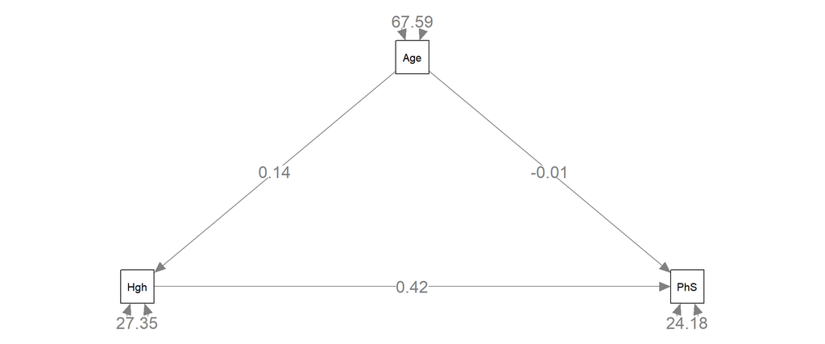

```r
require(semPlot)
semPaths(fitStr1, 'model','est', edge.label.cex = 1.1)
```

Calculation of the indirect and total effects:

```r
modelStrength<-'
Height~b*Age
PhysicalSt~a*Age+c*Height

##quantification of effects
dir := a
ind := b*c
tot := dir+ind
' #using := we can specify calculations in the sem. You can do any other type of calculaton also, eg. a^2
fitStr1<-sem(modelStrength, data=Babies)
summary(fitStr1)
```

```
## lavaan 0.6-7 ended normally after 15 iterations
##
##   Estimator                                         ML
##   Optimization method                           NLMINB
##   Number of free parameters                          5
##
##   Number of observations                           100
##
## Model Test User Model:
##
##   Test statistic                                 0.000
##   Degrees of freedom                                 0
##
## Parameter Estimates:
##
##   Standard errors                             Standard
##   Information                                 Expected
##   Information saturated (h1) model          Structured
##
## Regressions:
##                    Estimate  Std.Err  z-value  P(>|z|)
##   Height ~
##     Age        (b)    0.143    0.064    2.251    0.024
##   PhysicalSt ~
##     Age        (a)   -0.007    0.061   -0.120    0.905
##     Height     (c)    0.425    0.094    4.518    0.000
##
## Variances:
##                    Estimate  Std.Err  z-value  P(>|z|)
##    .Height           27.352    3.868    7.071    0.000
##    .PhysicalSt       24.183    3.420    7.071    0.000
##
## Defined Parameters:
##                    Estimate  Std.Err  z-value  P(>|z|)
##     dir              -0.007    0.061   -0.120    0.905
##     ind               0.061    0.030    2.015    0.044
##     tot               0.053    0.066    0.815    0.415
```

We can also specify more complex path model:

```r
modelStrength2<-'
Height~b*Age
Weight~e*Age
PhysicalSt~a*Age+c*Height+f*Weight

##quantification of effects
dir := a
ind := b*c+e*f
tot := dir+ind
'
```

```r
fitStr2<-sem(modelStrength2, data=Babies)
summary(fitStr2)
```

```
## lavaan 0.6-7 ended normally after 32 iterations
##
##   Estimator                                         ML
##   Optimization method                           NLMINB
##   Number of free parameters                          8
##
##   Number of observations                           100
##
## Model Test User Model:
##
##   Test statistic                                16.364
##   Degrees of freedom                                 1
##   P-value (Chi-square)                           0.000
##
## Parameter Estimates:
##
##   Standard errors                             Standard
##   Information                                 Expected
##   Information saturated (h1) model          Structured
##
## Regressions:
##                    Estimate    Std.Err   z-value  P(>|z|)
##   Height ~
##     Age        (b)      0.143     0.064    2.251    0.024
##   Weight ~
##     Age        (e)      2.439     5.774    0.422    0.673
##   PhysicalSt ~
##     Age        (a)     -0.005     0.061   -0.075    0.940
##     Height     (c)      0.387     0.094    4.138    0.000
##     Weight     (f)      0.001     0.001    1.032    0.302
##
## Variances:
##                    Estimate    Std.Err   z-value  P(>|z|)
##    .Height             27.352     3.868    7.071    0.000
##    .Weight         225306.345 31863.129    7.071    0.000
##    .PhysicalSt         23.966     3.389    7.071    0.000
##
## Defined Parameters:
##                    Estimate    Std.Err   z-value  P(>|z|)
##     dir                -0.005     0.061   -0.075    0.940
##     ind                 0.058     0.029    2.014    0.044
##     tot                 0.053     0.065    0.826    0.409
```

We can get all parameter estimates and bootstrap values

```r
parameterestimates(fitStr2, boot.ci.type ='bca.simple', standardized = T) #adding bca.simple we are getting bootstrapped intervals using adjusted bootstrap percentile method
```

```
##           lhs op        rhs label        est        se      z pvalue   ci.lower
## 1      Height  ~        Age     b      0.143     0.064  2.251  0.024      0.018
## 2      Weight  ~        Age     e      2.439     5.774  0.422  0.673     -8.878
## 3  PhysicalSt  ~        Age     a     -0.005     0.061 -0.075  0.940     -0.124
## 4  PhysicalSt  ~     Height     c      0.387     0.094  4.138  0.000      0.204
## 5  PhysicalSt  ~     Weight     f      0.001     0.001  1.032  0.302     -0.001
## 6      Height ~~     Height           27.352     3.868  7.071  0.000     19.771
## 7      Weight ~~     Weight       225306.345 31863.129  7.071  0.000 162855.760
## 8  PhysicalSt ~~ PhysicalSt           23.966     3.389  7.071  0.000     17.323
## 9         Age ~~        Age           67.588     0.000     NA     NA     67.588
## 10        dir :=          a   dir     -0.005     0.061 -0.075  0.940     -0.124
## 11        ind :=    b*c+e*f   ind      0.058     0.029  2.014  0.044      0.002
## 12        tot :=    dir+ind   tot      0.053     0.065  0.826  0.409     -0.073
##      ci.upper     std.lv std.all std.nox
## 1       0.268      0.143   0.220   0.027
## 2      13.755      2.439   0.042   0.005
## 3       0.115     -0.005  -0.007  -0.001
## 4       0.571      0.387   0.389   0.389
## 5       0.003      0.001   0.095   0.095
## 6      34.933     27.352   0.952   0.952
## 7  287756.930 225306.345   0.998   0.998
## 8      30.609     23.966   0.840   0.840
## 9      67.588     67.588   1.000  67.588
## 10      0.115     -0.005  -0.007  -0.001
## 11      0.115      0.058   0.089   0.011
## 12      0.180      0.053   0.082   0.010
```

Adding categorical predictors can be straightforward if they are exogenous:

```r
Babies$Gender=ifelse(Babies$Gender=='Girls',0,1)

modelStrength3<-'
Height~Age
PhysicalSt~Age+Height+Gender
'
fitStr3<-sem(modelStrength3, data=Babies)
summary(fitStr3)
```

```
## lavaan 0.6-7 ended normally after 21 iterations
##
##   Estimator                                         ML
##   Optimization method                           NLMINB
##   Number of free parameters                          6
##
##   Number of observations                           100
##
## Model Test User Model:
##
##   Test statistic                                 0.630
##   Degrees of freedom                                 1
##   P-value (Chi-square)                           0.427
##
## Parameter Estimates:
##
##   Standard errors                             Standard
##   Information                                 Expected
##   Information saturated (h1) model          Structured
##
## Regressions:
##                    Estimate  Std.Err  z-value  P(>|z|)
##   Height ~
##     Age               0.143    0.064    2.251    0.024
##   PhysicalSt ~
##     Age              -0.007    0.061   -0.116    0.907
##     Height            0.426    0.094    4.526    0.000
##     Gender            0.090    0.986    0.091    0.927
##
## Variances:
##                    Estimate  Std.Err  z-value  P(>|z|)
##    .Height           27.352    3.868    7.071    0.000
##    .PhysicalSt       24.181    3.420    7.071    0.000
```

But they are more problematic if categorical predictors are also endogenous

```r
modelStrength4<-'
Height~Age
Gender~Age
PhysicalSt~Age+Height+Gender
'
fitStr4<-sem(modelStrength4, ordered = c('Gender'),data=Babies) #in that case we need to specify which variables are categorical. In this situation, we are specifying that our categorical is ordered and our model assumes that categories are result of underlying gaussian process and will estimate thresholds. These thresholds are values that represent cut-off points between our groups. We do not have to estimate these thresholds, but we can manually specify them.
summary(fitStr4)
```

```
## lavaan 0.6-7 ended normally after 32 iterations
##
##   Estimator                                       DWLS
##   Optimization method                           NLMINB
##   Number of free parameters                         10
##
##   Number of observations                           100
##
## Model Test User Model:
##                                               Standard      Robust
##   Test Statistic                                 0.666       0.666
##   Degrees of freedom                                 1           1
##   P-value (Chi-square)                           0.415       0.415
##   Scaling correction factor                                  1.000
##   Shift parameter                                           -0.000
##        simple second-order correction
##
## Parameter Estimates:
##
##   Standard errors                           Robust.sem
##   Information                                 Expected
##   Information saturated (h1) model        Unstructured
##
## Regressions:
##                    Estimate  Std.Err  z-value  P(>|z|)
##   Height ~
##     Age               0.143    0.060    2.397    0.017
##   Gender ~
##     Age              -0.008    0.015   -0.545    0.586
##   PhysicalSt ~
##     Age              -0.009    0.071   -0.123    0.902
##     Height            0.425    0.098    4.322    0.000
##     Gender           -0.164    0.663   -0.248    0.804
##
## Intercepts:
##                    Estimate  Std.Err  z-value  P(>|z|)
##    .Height           57.026    1.172   48.649    0.000
##    .Gender            0.000
##    .PhysicalSt        5.678    5.801    0.979    0.328
##
## Thresholds:
##                    Estimate  Std.Err  z-value  P(>|z|)
##     Gender|t1        -0.189    0.284   -0.666    0.505
##
## Variances:
##                    Estimate  Std.Err  z-value  P(>|z|)
##    .Height           27.352    4.513    6.061    0.000
##    .Gender            1.000
##    .PhysicalSt       24.156    3.551    6.803    0.000
##
## Scales y*:
##                    Estimate  Std.Err  z-value  P(>|z|)
##     Gender            1.000
```

Conditional process analysis. We have both mediation and moderation:

```r
modelStrengthCond<-'
Height~Age
PhysicalSt~Age+Height+AgeGender
'
fitStrCond<-sem(modelStrengthCond, data=Babies)
summary(fitStrCond)
```

```
## lavaan 0.6-7 ended normally after 14 iterations
##
##   Estimator                                         ML
##   Optimization method                           NLMINB
##   Number of free parameters                          6
##
##   Number of observations                           100
##
## Model Test User Model:
##
##   Test statistic                                 1.628
##   Degrees of freedom                                 1
##   P-value (Chi-square)                           0.202
##
## Parameter Estimates:
##
##   Standard errors                             Standard
##   Information                                 Expected
##   Information saturated (h1) model          Structured
##
## Regressions:
##                    Estimate  Std.Err  z-value  P(>|z|)
##   Height ~
##     Age               0.143    0.064    2.251    0.024
##   PhysicalSt ~
##     Age              -0.008    0.066   -0.128    0.898
##     Height            0.425    0.094    4.524    0.000
##     AgeGender         0.002    0.053    0.043    0.966
##
## Variances:
##                    Estimate  Std.Err  z-value  P(>|z|)
##    .Height           27.352    3.868    7.071    0.000
##    .PhysicalSt       24.182    3.420    7.071    0.000
```

Fixing the predictors to a particular value:

```r
modelStrengthFix<-'
Height~Age
PhysicalSt~0  *Age+Height
' #inclusion of value in front of our predictor will fix our predictor to that particular value
fitStr1Fix<-sem(modelStrengthFix, data=Babies)
summary(fitStr1Fix)
```

```
## lavaan 0.6-7 ended normally after 18 iterations
##
##   Estimator                                         ML
##   Optimization method                           NLMINB
##   Number of free parameters                          4
##
##   Number of observations                           100
##
## Model Test User Model:
##
##   Test statistic                                 0.014
##   Degrees of freedom                                 1
##   P-value (Chi-square)                           0.905
##
## Parameter Estimates:
##
##   Standard errors                             Standard
##   Information                                 Expected
##   Information saturated (h1) model          Structured
##
## Regressions:
##                    Estimate  Std.Err  z-value  P(>|z|)
##   Height ~
##     Age               0.143    0.064    2.251    0.024
##   PhysicalSt ~
##     Age               0.000
##     Height            0.422    0.092    4.604    0.000
##
## Variances:
##                    Estimate  Std.Err  z-value  P(>|z|)
##    .Height           27.352    3.868    7.071    0.000
##    .PhysicalSt       24.186    3.420    7.071    0.000
```

Constraining parameters:

```r
modelStrengthCons<-'
Height~a*Age
PhysicalSt~a*Age+Height
' # we can also constrain two parameters. Effect of age on Height and on Physical strenght is constrained to the same value. Our mode is now estimating coefficient that will satisfy this constrain.
fitStr1Cons<-sem(modelStrengthCons, data=Babies)
summary(fitStr1Cons)
```

```
## lavaan 0.6-7 ended normally after 14 iterations
##
##   Estimator                                         ML
##   Optimization method                           NLMINB
##   Number of free parameters                          5
##   Number of equality constraints                     1
##
##   Number of observations                           100
##
## Model Test User Model:
##
##   Test statistic                                 2.882
##   Degrees of freedom                                 1
##   P-value (Chi-square)                           0.090
##
## Parameter Estimates:
##
##   Standard errors                             Standard
##   Information                                 Expected
##   Information saturated (h1) model          Structured
##
## Regressions:
##                    Estimate  Std.Err  z-value  P(>|z|)
##   Height ~
##     Age        (a)    0.065    0.044    1.479    0.139
##   PhysicalSt ~
##     Age        (a)    0.065    0.044    1.479    0.139
##     Height            0.400    0.094    4.271    0.000
##
## Variances:
##                    Estimate  Std.Err  z-value  P(>|z|)
##    .Height           27.764    3.926    7.071    0.000
##    .PhysicalSt       24.520    3.468    7.071    0.000
```

Practical aspect

Reading the data:

```r
NBAPath<-read.table('NBApath.txt', sep='\t', header=T)
```

We can summarise all variables in our dataset. We get type of summary based on our coding of the variables. Factors are being summarised with frequencies, numeric values with mean, min and max.

```r
summary(NBAPath)
```

```
##      TEAM                PCT            Player              Pos
##  Length:3810        Min.   :0.1061   Length:3810        Length:3810
##  Class :character   1st Qu.:0.3780   Class :character   Class :character
##  Mode  :character   Median :0.5000   Mode  :character   Mode  :character
##                     Mean   :0.4905
##                     3rd Qu.:0.6098
##                     Max.   :0.8902
##       Age              GP             PER
##  Min.   :18.00   Min.   : 1.00   Min.   :-13.10
##  1st Qu.:23.00   1st Qu.:34.00   1st Qu.: 10.00
##  Median :25.00   Median :61.00   Median : 12.80
##  Mean   :26.05   Mean   :53.73   Mean   : 12.75
##  3rd Qu.:29.00   3rd Qu.:77.00   3rd Qu.: 15.80
##  Max.   :43.00   Max.   :82.00   Max.   : 35.20
```

Correlation matrix:

```r
cor(NBAPath[,c(2,5:7)]) # I take only numeric variables
```

```
##            PCT        Age         GP        PER
## PCT 1.00000000 0.14304325 0.08849459 0.07720633
## Age 0.14304325 1.00000000 0.05170204 0.03598025
## GP  0.08849459 0.05170204 1.00000000 0.45360129
## PER 0.07720633 0.03598025 0.45360129 1.00000000
```

Density plots:

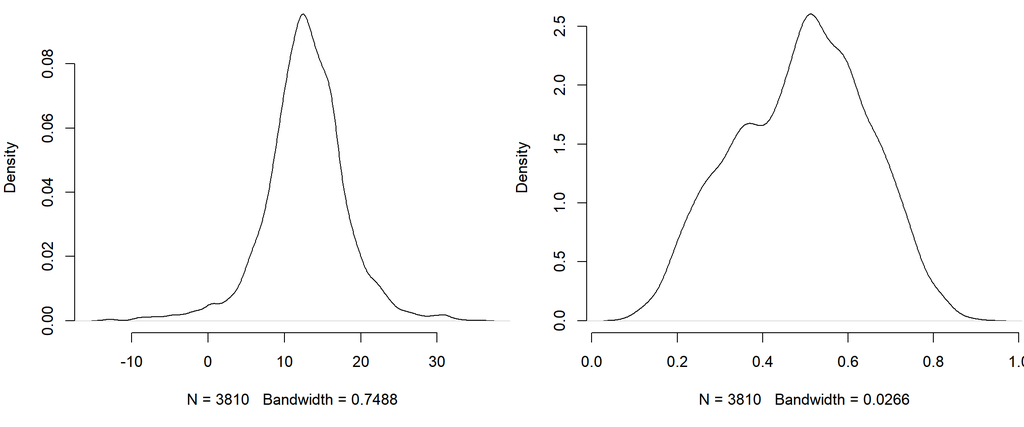

```r
par(mfrow=c(1,2), bty='n',mar = c(5, 4, .1, .1), cex=1.1, pch=16)
plot(density(NBAPath$PER), main='')
plot(density(NBAPath$PCT), main='')
```

Scatter plots:

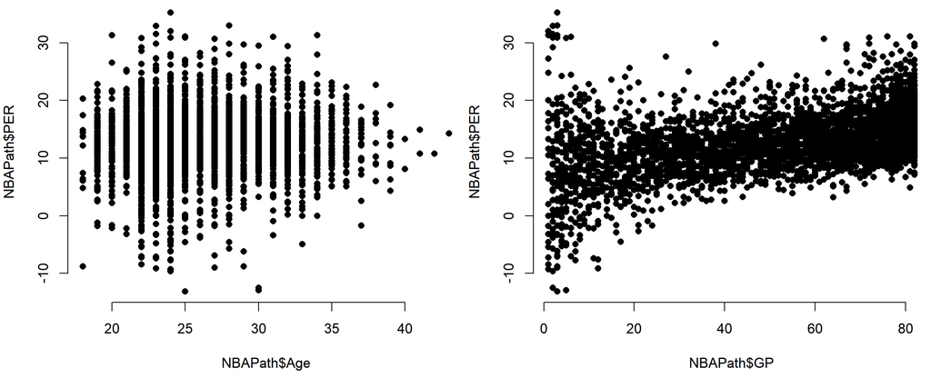

```r
par(mfrow=c(1,2), bty='n',mar = c(5, 4, .1, .1), cex=1.1, pch=16)
plot(NBAPath$Age, NBAPath$PER)
plot(NBAPath$GP, NBAPath$PER)
```

First specification of the model:

```r
NBAmod1<-'
GP~b*Age
PER~a*Age+c*GP

dir := a
ind := b*c
tot := dir + ind
'
NBAfit1<-sem(NBAmod1, data=NBAPath)
summary(NBAfit1)
```

```
## lavaan 0.6-7 ended normally after 21 iterations
##
##   Estimator                                         ML
##   Optimization method                           NLMINB
##   Number of free parameters                          5
##
##   Number of observations                          3810
##
## Model Test User Model:
##
##   Test statistic                                 0.000
##   Degrees of freedom                                 0
##
## Parameter Estimates:
##
##   Standard errors                             Standard
##   Information                                 Expected
##   Information saturated (h1) model          Structured
##
## Regressions:
##                    Estimate  Std.Err  z-value  P(>|z|)
##   GP ~
##     Age        (b)    0.315    0.098    3.196    0.001
##   PER ~
##     Age        (a)    0.016    0.018    0.869    0.385
##     GP         (c)    0.093    0.003   31.333    0.000
##
## Variances:
##                    Estimate  Std.Err  z-value  P(>|z|)
##    .GP              645.883   14.798   43.646    0.000
##    .PER              21.834    0.500   43.646    0.000
##
## Defined Parameters:
##                    Estimate  Std.Err  z-value  P(>|z|)
##     dir               0.016    0.018    0.869    0.385
##     ind               0.029    0.009    3.179    0.001
##     tot               0.045    0.020    2.222    0.026
```

We can calculate coefficient of determination:

```r
inspect(NBAfit1, 'r2')
```

```
##    GP   PER
## 0.003 0.206
```

```r
-2*logLik(NBAfit1) # deviance
```

```
## 'log Lik.' 58025.67 (df=5)
```

```r
AIC(NBAfit1) # Akaike information criterion
```

```
## [1] 58035.67
```

Respecification of the model

```r
NBAmod2<-'
GP~b*Age
PER~c*GP

ind := b*c
'
NBAfit2<-sem(NBAmod2, data=NBAPath)
summary(NBAfit2, fit.measures=T)
```

```
## lavaan 0.6-7 ended normally after 21 iterations
##
##   Estimator                                         ML
##   Optimization method                           NLMINB
##   Number of free parameters                          4
##
##   Number of observations                          3810
##
## Model Test User Model:
##
##   Test statistic                                 0.755
##   Degrees of freedom                                 1
##   P-value (Chi-square)                           0.385
##
## Model Test Baseline Model:
##
##   Test statistic                               888.633
##   Degrees of freedom                                 3
##   P-value                                        0.000
##
## User Model versus Baseline Model:
##
##   Comparative Fit Index (CFI)                    1.000
##   Tucker-Lewis Index (TLI)                       1.001
##
## Loglikelihood and Information Criteria:
##
##   Loglikelihood user model (H0)             -29013.211
##   Loglikelihood unrestricted model (H1)     -29012.833
##
##   Akaike (AIC)                               58034.422
##   Bayesian (BIC)                             58059.403
##   Sample-size adjusted Bayesian (BIC)        58046.693
##
## Root Mean Square Error of Approximation:
##
##   RMSEA                                          0.000
##   90 Percent confidence interval - lower         0.000
##   90 Percent confidence interval - upper         0.041
##   P-value RMSEA <= 0.05                          0.987
```

[output cut: 11 more lines]

```
## Regressions:
##                    Estimate  Std.Err  z-value  P(>|z|)
##   GP ~
##     Age        (b)    0.315    0.098    3.196    0.001
##   PER ~
##     GP         (c)    0.093    0.003   31.417    0.000
##
## Variances:
##                    Estimate  Std.Err  z-value  P(>|z|)
##    .GP              645.883   14.798   43.646    0.000
##    .PER              21.838    0.500   43.646    0.000
##
## Defined Parameters:
##                    Estimate  Std.Err  z-value  P(>|z|)
##     ind               0.029    0.009    3.179    0.001
```

Comparing the models:

```r
#install.packages('semTools')
require(semTools)
diff<-compareFit(NBAfit1, NBAfit2)
summary(diff)
```

```
## ################### Nested Model Comparison #########################
## Chi-Squared Difference Test
##
##         Df   AIC   BIC Chisq Chisq diff Df diff Pr(>Chisq)
## NBAfit1  0 58036 58067 0.000
## NBAfit2  1 58034 58059 0.755      0.755       1     0.3849
##
## ####################### Model Fit Indices ###########################
##         chisq df pvalue    cfi    tli        aic        bic rmsea  srmr
## NBAfit1 .000†        NA 1.000† 1.000  58035.667  58066.894  .000† .000†
## NBAfit2 .755   1   .385 1.000† 1.001† 58034.422† 58059.403† .000† .005
##
## ################## Differences in Fit Indices #######################
##                   df cfi   tli    aic   bic rmsea  srmr
## NBAfit2 - NBAfit1  1   0 0.001 -1.245 -7.49     0 0.005
```

Respecification of the model:

```r
NBAmod3<-'
GP~b*Age
PER~a*Age+c*GP
PCT~d*PER
ind1 := b*c*d
ind2 := a*d
tot := ind1 + ind2
'
NBAfit3<-sem(NBAmod3, data=NBAPath)
summary(NBAfit3, fit.measures=T)
```

```
## lavaan 0.6-7 ended normally after 30 iterations
##
##   Estimator                                         ML
##   Optimization method                           NLMINB
##   Number of free parameters                          7
##
##   Number of observations                          3810
##
## Model Test User Model:
##
##   Test statistic                                87.884
##   Degrees of freedom                                 2
##   P-value (Chi-square)                           0.000
##
## Model Test Baseline Model:
##
##   Test statistic                               999.296
##   Degrees of freedom                                 6
##   P-value                                        0.000
##
## User Model versus Baseline Model:
##
##   Comparative Fit Index (CFI)                    0.914
##   Tucker-Lewis Index (TLI)                       0.741
##
## Loglikelihood and Information Criteria:
##
##   Loglikelihood user model (H0)             -27272.876
##   Loglikelihood unrestricted model (H1)     -27228.934
##
##   Akaike (AIC)                               54559.752
##   Bayesian (BIC)                             54603.469
##   Sample-size adjusted Bayesian (BIC)        54581.227
##
## Root Mean Square Error of Approximation:
##
##   RMSEA                                          0.106
##   90 Percent confidence interval - lower         0.088
##   90 Percent confidence interval - upper         0.126
##   P-value RMSEA <= 0.05                          0.000
```

[output cut: 17 more lines]

```
##     GP         (c)    0.093    0.003   31.333    0.000
##   PCT ~
##     PER        (d)    0.002    0.000    4.780    0.000
##
## Variances:
##                    Estimate  Std.Err  z-value  P(>|z|)
##    .GP              645.883   14.798   43.646    0.000
##    .PER              21.834    0.500   43.646    0.000
##    .PCT               0.023    0.001   43.646    0.000
##
## Defined Parameters:
##                    Estimate  Std.Err  z-value  P(>|z|)
##     ind1              0.000    0.000    2.647    0.008
##     ind2              0.000    0.000    0.855    0.393
##     tot               0.000    0.000    2.015    0.044
```